# Unsupervised Machine Learning with Scikit-learn

[figure not shown]

Unsupervised ML: use of unlabeled data for training

- The systems tries to learn without a teacher
- You are not given a target value/label that you are to predict the outcome as
- We only have the independent variables(x) and no target/dependent variable(y) in these problems.

#### Libraries

- pandas
- scikit-learn
- pycaret
- hdbscan

#### Types of UML Algorithms

- Clustering
- Anomaly Detection:outlier detection
- Novelty Detection:
- Visualization
- Dimensionality Reduction:simplify data without losing too much info by merging correlated features into one
- Association Rule Learning:discovering interesting relations btwn attributes

#### Clustering Unsupervised ML Task

- Clustering:
  - The process of grouping dataset in to groups in such a way that similar datapoints are in the same group
  - Usefulness
    - EDA
    - Pattern Recognition
    - Image Analysis
    - For working with unlabelled data
    - Search engines image search
    - Customer segmentation
    - Market segmentation
    - Outlier Detection
    - clustering similar documents together,
    - recommending similar songs or movies,

#### Types of Clustering

- Flat vs Hierarchical
- Centroid Based vs Density Based

[figure not shown]

#### Basic Principle Behind Clustering

All are based on different distance measures.

- K-Means (distance between points),
- Affinity propagation (graph distance),
- Mean-shift (distance between points),
- DBSCAN (distance between nearest points),
- Gaussian mixtures (Mahalanobis distance to centers),
- Spectral clustering (graph distance), etc.

#### Terms

- Centroid: a data point at the center of a group/cluster

### Clustering using KMeans Algorithm

- Kmeans(Lloyd Forgy Algorithm)
- MiniBatchKmeans

#### Benefits

- Fast and Scalable

#### Demerits

- Need to know th number of clusters
- problem of having to pre-define the number of clusters.
  - Elbow Method/Silhoutte Method
  - Hierarchical Clustering:
- Varying sizes and different densities may affect performance
  - scaling

#### Terms

- k = number of clusters
- .label_: index of cluster
- .cluster*centers*: centroid
- .inertia_: performance metric of mean sq distance btwn each instance and its closest centroid

#### Task

- Find the different clusters
- Customer segmentation
  - Different types of customer/buyers in a market

## Data Preprocessing

This is the cleaning and modeling the data into a format which can be used by various clustering models we would be addressing. Some of these issues addressed would be:

- Handling empty cells
- Handling duplicated cells
- Handling irrelevant features

###### Importing all required libraries and data

```python
# importing all necessary libraries
import numpy as np
import pandas as pd
import matplotlib.pyplot as plt
import matplotlib.cm as cm
import seaborn as sns
from sklearn.preprocessing import StandardScaler
from sklearn.decomposition import PCA
from sklearn.cluster import KMeans,AgglomerativeClustering,DBSCAN,SpectralClustering
from sklearn.mixture import GaussianMixture
from sklearn.metrics import silhouette_samples, silhouette_score
from sklearn.tree import DecisionTreeClassifier
from sklearn.model_selection import train_test_split
from sklearn.metrics import classification_report
from sklearn import tree
from sklearn import metrics
import warnings
warnings.filterwarnings('ignore')


#Load Dataset
df = pd.read_csv('Customer_Data.csv')
```

# Data Exploration and Visualization

```python
print("THE TOP 6 ROWS OF THE DATA IN CONSIDERATION WHICH WAS IMPORTED IN THE PREVIOUS CELL cell")
print("--"*100,"\n")
df.head(6)
```

```
THE TOP 6 ROWS OF THE DATA IN CONSIDERATION WHICH WAS IMPORTED IN THE PREVIOUS CELL cell
--------------------------------------------------------------------------------------------------------------------------------------------------------------------------------------------------------
```

|  | CUST_ID | BALANCE | BALANCE_FREQUENCY | PURCHASES | ONEOFF_PURCHASES | INSTALLMENTS_PURCHASES | CASH_ADVANCE | PURCHASES_FREQUENCY | ONEOFF_PURCHASES_FREQUENCY | PURCHASES_INSTALLMENTS_FREQUENCY | CASH_ADVANCE_FREQUENCY | CASH_ADVANCE_TRX | PURCHASES_TRX | CREDIT_LIMIT | PAYMENTS | MINIMUM_PAYMENTS | PRC_FULL_PAYMENT | TENURE |
| --- | --- | --- | --- | --- | --- | --- | --- | --- | --- | --- | --- | --- | --- | --- | --- | --- | --- | --- |
| 0 | C10001 | 40.900749 | 0.818182 | 95.40 | 0.00 | 95.40 | 0.000000 | 0.166667 | 0.000000 | 0.083333 | 0.000000 | 0 | 2 | 1000.0 | 201.802084 | 139.509787 | 0.000000 | 12 |
| 1 | C10002 | 3202.467416 | 0.909091 | 0.00 | 0.00 | 0.00 | 6442.945483 | 0.000000 | 0.000000 | 0.000000 | 0.250000 | 4 | 0 | 7000.0 | 4103.032597 | 1072.340217 | 0.222222 | 12 |
| 2 | C10003 | 2495.148862 | 1.000000 | 773.17 | 773.17 | 0.00 | 0.000000 | 1.000000 | 1.000000 | 0.000000 | 0.000000 | 0 | 12 | 7500.0 | 622.066742 | 627.284787 | 0.000000 | 12 |
| 3 | C10004 | 1666.670542 | 0.636364 | 1499.00 | 1499.00 | 0.00 | 205.788017 | 0.083333 | 0.083333 | 0.000000 | 0.083333 | 1 | 1 | 7500.0 | 0.000000 | NaN | 0.000000 | 12 |
| 4 | C10005 | 817.714335 | 1.000000 | 16.00 | 16.00 | 0.00 | 0.000000 | 0.083333 | 0.083333 | 0.000000 | 0.000000 | 0 | 1 | 1200.0 | 678.334763 | 244.791237 | 0.000000 | 12 |
| 5 | C10006 | 1809.828751 | 1.000000 | 1333.28 | 0.00 | 1333.28 | 0.000000 | 0.666667 | 0.000000 | 0.583333 | 0.000000 | 0 | 8 | 1800.0 | 1400.057770 | 2407.246035 | 0.000000 | 12 |

```python
print("There are {} rows and {} columns present in the dataset\n".format(df.shape[0],df.shape[1]))
# print(df.shape)
```

```
There are 8950 rows and 18 columns present in the dataset
```

```python
print("STRUCTURE OF THE DATA")
print("--"*100,"\n")
df.info()
```

```
STRUCTURE OF THE DATA
--------------------------------------------------------------------------------------------------------------------------------------------------------------------------------------------------------

<class 'pandas.core.frame.DataFrame'>
RangeIndex: 8950 entries, 0 to 8949
Data columns (total 18 columns):
 #   Column                            Non-Null Count  Dtype
---  ------                            --------------  -----
 0   CUST_ID                           8950 non-null   object
 1   BALANCE                           8950 non-null   float64
 2   BALANCE_FREQUENCY                 8950 non-null   float64
 3   PURCHASES                         8950 non-null   float64
 4   ONEOFF_PURCHASES                  8950 non-null   float64
 5   INSTALLMENTS_PURCHASES            8950 non-null   float64
 6   CASH_ADVANCE                      8950 non-null   float64
 7   PURCHASES_FREQUENCY               8950 non-null   float64
 8   ONEOFF_PURCHASES_FREQUENCY        8950 non-null   float64
 9   PURCHASES_INSTALLMENTS_FREQUENCY  8950 non-null   float64
 10  CASH_ADVANCE_FREQUENCY            8950 non-null   float64
 11  CASH_ADVANCE_TRX                  8950 non-null   int64
 12  PURCHASES_TRX                     8950 non-null   int64
 13  CREDIT_LIMIT                      8949 non-null   float64
 14  PAYMENTS                          8950 non-null   float64
 15  MINIMUM_PAYMENTS                  8637 non-null   float64
 16  PRC_FULL_PAYMENT                  8950 non-null   float64
 17  TENURE                            8950 non-null   int64
dtypes: float64(14), int64(3), object(1)
memory usage: 1.2+ MB
```

```python
print("DISCRIPTIVE STATISTICS OF THE DATA")
print("--"*100,"\n")
df.describe()
```

```
DISCRIPTIVE STATISTICS OF THE DATA
--------------------------------------------------------------------------------------------------------------------------------------------------------------------------------------------------------
```

|  | BALANCE | BALANCE_FREQUENCY | PURCHASES | ONEOFF_PURCHASES | INSTALLMENTS_PURCHASES | CASH_ADVANCE | PURCHASES_FREQUENCY | ONEOFF_PURCHASES_FREQUENCY | PURCHASES_INSTALLMENTS_FREQUENCY | CASH_ADVANCE_FREQUENCY | CASH_ADVANCE_TRX | PURCHASES_TRX | CREDIT_LIMIT | PAYMENTS | MINIMUM_PAYMENTS | PRC_FULL_PAYMENT | TENURE |
| --- | --- | --- | --- | --- | --- | --- | --- | --- | --- | --- | --- | --- | --- | --- | --- | --- | --- |
| count | 8950.000000 | 8950.000000 | 8950.000000 | 8950.000000 | 8950.000000 | 8950.000000 | 8950.000000 | 8950.000000 | 8950.000000 | 8950.000000 | 8950.000000 | 8950.000000 | 8949.000000 | 8950.000000 | 8637.000000 | 8950.000000 | 8950.000000 |
| mean | 1564.474828 | 0.877271 | 1003.204834 | 592.437371 | 411.067645 | 978.871112 | 0.490351 | 0.202458 | 0.364437 | 0.135144 | 3.248827 | 14.709832 | 4494.449450 | 1733.143852 | 864.206542 | 0.153715 | 11.517318 |
| std | 2081.531879 | 0.236904 | 2136.634782 | 1659.887917 | 904.338115 | 2097.163877 | 0.401371 | 0.298336 | 0.397448 | 0.200121 | 6.824647 | 24.857649 | 3638.815725 | 2895.063757 | 2372.446607 | 0.292499 | 1.338331 |
| min | 0.000000 | 0.000000 | 0.000000 | 0.000000 | 0.000000 | 0.000000 | 0.000000 | 0.000000 | 0.000000 | 0.000000 | 0.000000 | 0.000000 | 50.000000 | 0.000000 | 0.019163 | 0.000000 | 6.000000 |
| 25% | 128.281915 | 0.888889 | 39.635000 | 0.000000 | 0.000000 | 0.000000 | 0.083333 | 0.000000 | 0.000000 | 0.000000 | 0.000000 | 1.000000 | 1600.000000 | 383.276166 | 169.123707 | 0.000000 | 12.000000 |
| 50% | 873.385231 | 1.000000 | 361.280000 | 38.000000 | 89.000000 | 0.000000 | 0.500000 | 0.083333 | 0.166667 | 0.000000 | 0.000000 | 7.000000 | 3000.000000 | 856.901546 | 312.343947 | 0.000000 | 12.000000 |
| 75% | 2054.140036 | 1.000000 | 1110.130000 | 577.405000 | 468.637500 | 1113.821139 | 0.916667 | 0.300000 | 0.750000 | 0.222222 | 4.000000 | 17.000000 | 6500.000000 | 1901.134317 | 825.485459 | 0.142857 | 12.000000 |
| max | 19043.138560 | 1.000000 | 49039.570000 | 40761.250000 | 22500.000000 | 47137.211760 | 1.000000 | 1.000000 | 1.000000 | 1.500000 | 123.000000 | 358.000000 | 30000.000000 | 50721.483360 | 76406.207520 | 1.000000 | 12.000000 |

Checking for the presence of null values or empty cells. Addressing this issue will help in a better performance of our various model.

There are several ways empty cells can be handled, a few are:

- Replacing the cells with the maximum value of the observation
- Replacing with minimum value of the observation
- Replacing with the average value of the observation
- Replacing with mode frequent value of the observed column and various other value imputation method

```python
# checking for null values
print(df.isnull().sum())
```

```
CUST_ID                               0
BALANCE                               0
BALANCE_FREQUENCY                     0
PURCHASES                             0
ONEOFF_PURCHASES                      0
INSTALLMENTS_PURCHASES                0
CASH_ADVANCE                          0
PURCHASES_FREQUENCY                   0
ONEOFF_PURCHASES_FREQUENCY            0
PURCHASES_INSTALLMENTS_FREQUENCY      0
CASH_ADVANCE_FREQUENCY                0
CASH_ADVANCE_TRX                      0
PURCHASES_TRX                         0
CREDIT_LIMIT                          1
PAYMENTS                              0
MINIMUM_PAYMENTS                    313
PRC_FULL_PAYMENT                      0
TENURE                                0
dtype: int64
```

From the above output we have the Minimum Payment column (or feature) with 313 empty cells or observation and Credit limit feature with 1 empty cell.

The method used in replacing this various empty cells would be the mean or average value imputation method, i.e using the average value for the various columns to replace this empty cells.

```python
# Replacing all nan values in the minimum payments columns with the mean value of the minimum payment value
df.MINIMUM_PAYMENTS.fillna(value=df.MINIMUM_PAYMENTS.mean(), inplace=True)
print('*********We now have {} number of empty cells in the Minimum Payments feature********\n\n'.format(df.MINIMUM_PAYMENTS.isnull().sum()))


# Replacing all the nan values in the credit_limit column with the the mean value of the credit_limit column
df.CREDIT_LIMIT.fillna(value=df.CREDIT_LIMIT.mean(), inplace=True)
print("*********We now have {} numbers of empty cells in the Credit limit feature*******\n\n".format(df.CREDIT_LIMIT.isnull().sum()))

# checking for duplicates
print("Checking for duplicated observations---------- \n\n Found {} duplicates in the dataset\n\n".format(df.duplicated().sum()))


# Dropping irrelevant columns
print("Removing irrelevant features-------------------\n\n")
print("CUST_ID is confirmed to be irrelavant and is being dropped-----------------\n\n")
df.drop(columns=['CUST_ID'], axis=1, inplace=True)

# confirming no presence of null values
print("CONFIRMING FOR THE PRECENSE OR EMPTY CELLS AGAIN")
print("--"*100,"\n\n")
print(df.isnull().sum())
```

```
*********We now have 0 number of empty cells in the Minimum Payments feature********


*********We now have 0 numbers of empty cells in the Credit limit feature*******


Checking for duplicated observations----------

 Found 0 duplicates in the dataset


Removing irrelevant features-------------------


CUST_ID is confirmed to be irrelavant and is being dropped-----------------


CONFIRMING FOR THE PRECENSE OR EMPTY CELLS AGAIN
--------------------------------------------------------------------------------------------------------------------------------------------------------------------------------------------------------


BALANCE                             0
BALANCE_FREQUENCY                   0
PURCHASES                           0
ONEOFF_PURCHASES                    0
INSTALLMENTS_PURCHASES              0
CASH_ADVANCE                        0
PURCHASES_FREQUENCY                 0
ONEOFF_PURCHASES_FREQUENCY          0
PURCHASES_INSTALLMENTS_FREQUENCY    0
CASH_ADVANCE_FREQUENCY              0
CASH_ADVANCE_TRX                    0
PURCHASES_TRX                       0
CREDIT_LIMIT                        0
PAYMENTS                            0
MINIMUM_PAYMENTS                    0
PRC_FULL_PAYMENT                    0
TENURE                              0
dtype: int64
```

From the above output, it is evident that there are no empty cells anymore, and all duplicated and irrelevant features such as the CUST_ID which stands for the customer ID has been treated.

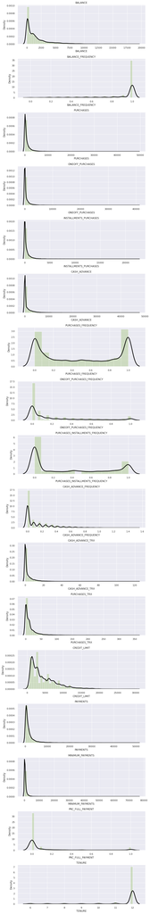

```python
plt.figure(figsize=(10,60))
for i in range(0,17):
    plt.subplot(17,1,i+1)
    sns.set_style('darkgrid')
    sns.set_context("notebook")
    sns.distplot(df[df.columns[i]],kde_kws={'color':'black','bw': 0.1,'lw':3,'label':'KDE'},hist_kws={'color':'g'})
    plt.title(df.columns[i])
plt.tight_layout()
```

### Heatmap

The heatmap is a graphical representation of data that uses a system of color-coding to represent different values. Here we can see that what the heatmap or heat map really does is it colors in those values based on some sort of gradient scale. It can be used to detect correlations, in our case, correlation between the features. Thus, the closer the annotated value is to 1 the higher the correlation or using the color scale we say the brighter the color the higher the correlation.

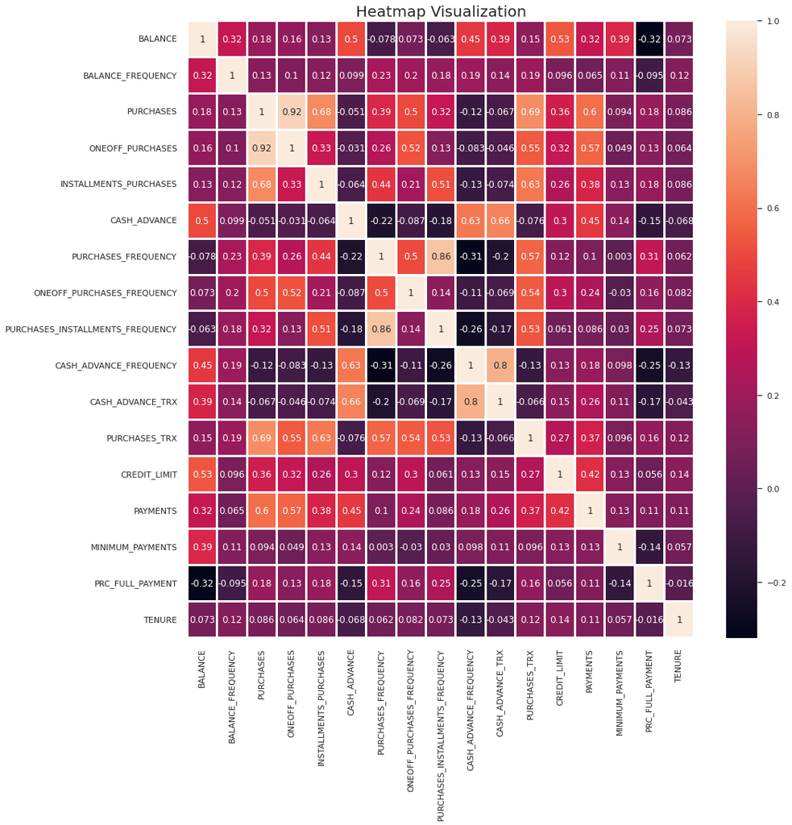

```python
#use of heatmap to visualize
plt.figure(figsize=(15,15))
sns.set_context("notebook")
sns.heatmap(df.corr(), annot=True,linecolor='white', linewidths=2)
plt.title("Heatmap Visualization", fontsize=20)
plt.show()
```

### Cluster Mapping

This visual method uses a hierarchical clusters to order data by similarity. This reorganizes the data for the rows and columns and displays similar content next to one another for even more and better depth of understanding the data.

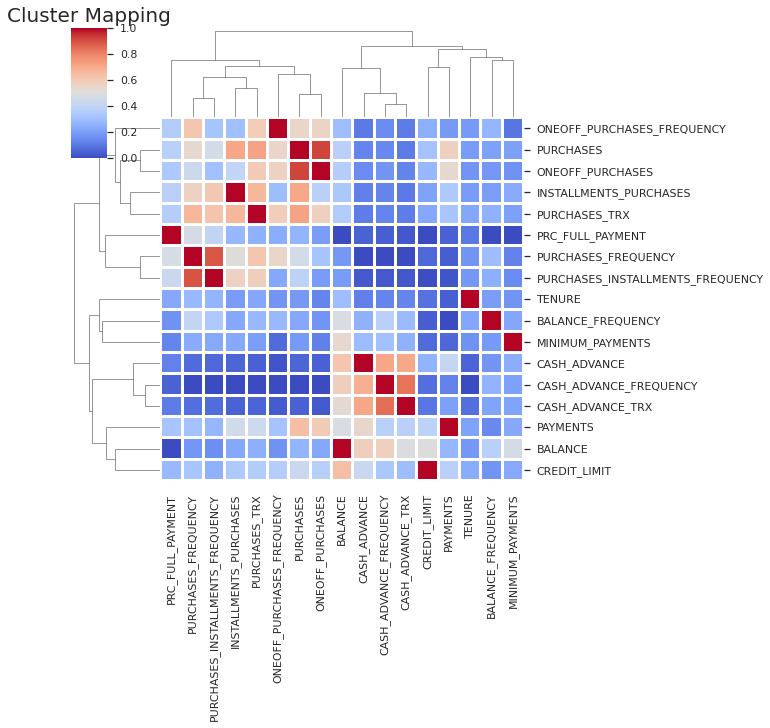

```python
#use of clusteredmap to visualize
plt.figure(figsize=(15,15))
sns.set_context("notebook")
sns.clustermap(df.corr(), cmap='coolwarm',standard_scale=1,linecolor='white', linewidths=2)
plt.title("Cluster Mapping", fontsize=20)
plt.show();
```

# Feature Scaling

Feature scaling is a method used to normalize the range of independent variables or features of data processing. It is also known as data normalization and is generally performed during the data preprocessing step.

Scaling the features makes the flow of gradient descent smooth and helps algorithms quickly reach the minima cost function.

Without scaling the features the algorithm may be biased towards the features which has values higher in magnitude.

- Feature scaling refers to the methods used to normalize the range of values of independent variables.
- In other words, the methods to set the feature value range within a similar scale.
- Feature scaling is generally the last step in the data preprocessing pipeline, performed just before training the machine learning algorithms.

Scaling methods

- Standardisation
- Mean normalisation
- Scaling to maximum and minimum
- Scaling to absolute maximum
- Scaling to median and quantiles
- Scaling to unit norm

For this project we will only be considering the Standardisation scaling method

## Standardisation

Standardisation involves centering the variable at zero, and standardising the variance to 1. The procedure involves subtracting the mean of each observation and then dividing by the standard deviation:

**z = (x - x_mean) / std**

The result of the above transformation is **z**, which is called the z-score, and represents how many standard deviations a given observation deviates from the mean. A z-score specifies the location of the observation within a distribution (in numbers of standard deviations respect to the mean of the distribution). The sign of the z-score (+ or - ) indicates whether the observation is above (+) or below ( - ) the mean.

In a nutshell, standardisation:

- centers the mean at 0
- scales the variance at 1
- preserves the shape of the original distribution
- the minimum and maximum values of the different variables may vary
- preserves outliers

Good for algorithms that require features centered at zero.

```python
# calling the data (i.e df) and checking the description
df.describe().head(3)
```

|  | BALANCE | BALANCE_FREQUENCY | PURCHASES | ONEOFF_PURCHASES | INSTALLMENTS_PURCHASES | CASH_ADVANCE | PURCHASES_FREQUENCY | ONEOFF_PURCHASES_FREQUENCY | PURCHASES_INSTALLMENTS_FREQUENCY | CASH_ADVANCE_FREQUENCY | CASH_ADVANCE_TRX | PURCHASES_TRX | CREDIT_LIMIT | PAYMENTS | MINIMUM_PAYMENTS | PRC_FULL_PAYMENT | TENURE |
| --- | --- | --- | --- | --- | --- | --- | --- | --- | --- | --- | --- | --- | --- | --- | --- | --- | --- |
| count | 8950.000000 | 8950.000000 | 8950.000000 | 8950.000000 | 8950.000000 | 8950.000000 | 8950.000000 | 8950.000000 | 8950.000000 | 8950.000000 | 8950.000000 | 8950.000000 | 8950.000000 | 8950.000000 | 8950.000000 | 8950.000000 | 8950.000000 |
| mean | 1564.474828 | 0.877271 | 1003.204834 | 592.437371 | 411.067645 | 978.871112 | 0.490351 | 0.202458 | 0.364437 | 0.135144 | 3.248827 | 14.709832 | 4494.449450 | 1733.143852 | 864.206542 | 0.153715 | 11.517318 |
| std | 2081.531879 | 0.236904 | 2136.634782 | 1659.887917 | 904.338115 | 2097.163877 | 0.401371 | 0.298336 | 0.397448 | 0.200121 | 6.824647 | 24.857649 | 3638.612411 | 2895.063757 | 2330.588021 | 0.292499 | 1.338331 |

The different variables present different value ranges, mean, max, min, standard deviations, etc. In other words, they show different magnitudes or scales. Note for this demo, how **the mean values are not centered at zero, and the standard deviations are not scaled to 1**.

Now the following code below will be to standardizing the data

```python
#using scikit learn standardscaler fuction to scale dataset
scalar = StandardScaler().fit_transform(df)
column_names = list(df.columns)

scaled_df = pd.DataFrame(data=scalar, columns=column_names)


print("STANDARDIZED SCALED DATA","\n","--"*100,"\n")
scaled_df.head(3)
```

```
STANDARDIZED SCALED DATA
 --------------------------------------------------------------------------------------------------------------------------------------------------------------------------------------------------------
```

|  | BALANCE | BALANCE_FREQUENCY | PURCHASES | ONEOFF_PURCHASES | INSTALLMENTS_PURCHASES | CASH_ADVANCE | PURCHASES_FREQUENCY | ONEOFF_PURCHASES_FREQUENCY | PURCHASES_INSTALLMENTS_FREQUENCY | CASH_ADVANCE_FREQUENCY | CASH_ADVANCE_TRX | PURCHASES_TRX | CREDIT_LIMIT | PAYMENTS | MINIMUM_PAYMENTS | PRC_FULL_PAYMENT | TENURE |
| --- | --- | --- | --- | --- | --- | --- | --- | --- | --- | --- | --- | --- | --- | --- | --- | --- | --- |
| 0 | -0.731989 | -0.249434 | -0.424900 | -0.356934 | -0.349079 | -0.466786 | -0.806490 | -0.678661 | -0.707313 | -0.675349 | -0.476070 | -0.511333 | -0.960433 | -0.528979 | -0.310968 | -0.525551 | 0.36068 |
| 1 | 0.786961 | 0.134325 | -0.469552 | -0.356934 | -0.454576 | 2.605605 | -1.221758 | -0.678661 | -0.916995 | 0.573963 | 0.110074 | -0.591796 | 0.688639 | 0.818642 | 0.089310 | 0.234227 | 0.36068 |
| 2 | 0.447135 | 0.518084 | -0.107668 | 0.108889 | -0.454576 | -0.466786 | 1.269843 | 2.673451 | -0.916995 | -0.675349 | -0.476070 | -0.109020 | 0.826062 | -0.383805 | -0.101663 | -0.525551 | 0.36068 |

Above is the standardised scaled data using the standardised scaling method implemented with the scikit learn preprocessing python library.

### Standardisation

The StandardScaler from scikit-learn removes the mean and scales the data to unit variance. Plus, it learns and stores the parameters needed for scaling. Thus, it is top choice for this feature scaling technique.

On the downside, you can't select which variables to scale directly, it will scale the entire data set, and it returns a NumPy array, without the variable values.

```python
np.round(scaled_df.describe(), 1).head(3)
```

|  | BALANCE | BALANCE_FREQUENCY | PURCHASES | ONEOFF_PURCHASES | INSTALLMENTS_PURCHASES | CASH_ADVANCE | PURCHASES_FREQUENCY | ONEOFF_PURCHASES_FREQUENCY | PURCHASES_INSTALLMENTS_FREQUENCY | CASH_ADVANCE_FREQUENCY | CASH_ADVANCE_TRX | PURCHASES_TRX | CREDIT_LIMIT | PAYMENTS | MINIMUM_PAYMENTS | PRC_FULL_PAYMENT | TENURE |
| --- | --- | --- | --- | --- | --- | --- | --- | --- | --- | --- | --- | --- | --- | --- | --- | --- | --- |
| count | 8950.0 | 8950.0 | 8950.0 | 8950.0 | 8950.0 | 8950.0 | 8950.0 | 8950.0 | 8950.0 | 8950.0 | 8950.0 | 8950.0 | 8950.0 | 8950.0 | 8950.0 | 8950.0 | 8950.0 |
| mean | 0.0 | 0.0 | -0.0 | 0.0 | 0.0 | 0.0 | -0.0 | 0.0 | 0.0 | 0.0 | -0.0 | -0.0 | -0.0 | -0.0 | 0.0 | -0.0 | 0.0 |
| std | 1.0 | 1.0 | 1.0 | 1.0 | 1.0 | 1.0 | 1.0 | 1.0 | 1.0 | 1.0 | 1.0 | 1.0 | 1.0 | 1.0 | 1.0 | 1.0 | 1.0 |

Recall, that it was noted that the Standardised scaling method gives a general mean of 0 and a general standard deviation of 1. This can be noticed from the above table at the **mean** and **std** rows

So, as expected, the mean of each variable, which were not centered at zero, is now around zero and the standard deviation is set to 1.

Note however, that the minimum and maximum values vary according to how spread the variable was to begin with and is highly influenced by the presence of outliers.

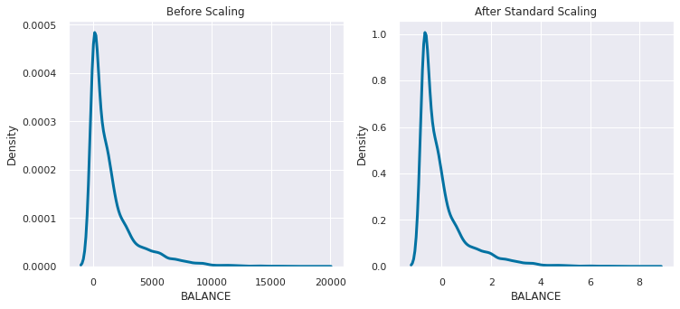

```
None
```

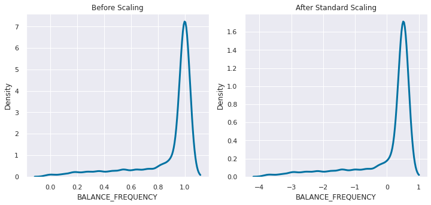

```
None
```

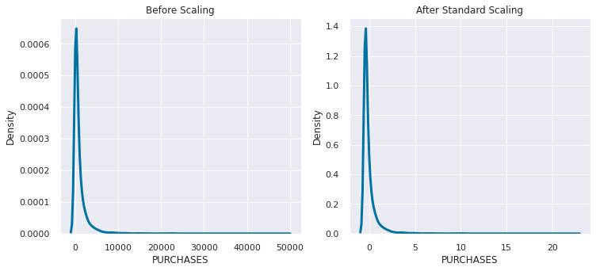

```
None
```

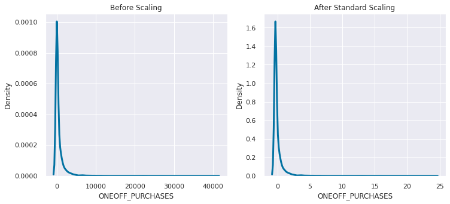

```
None
```

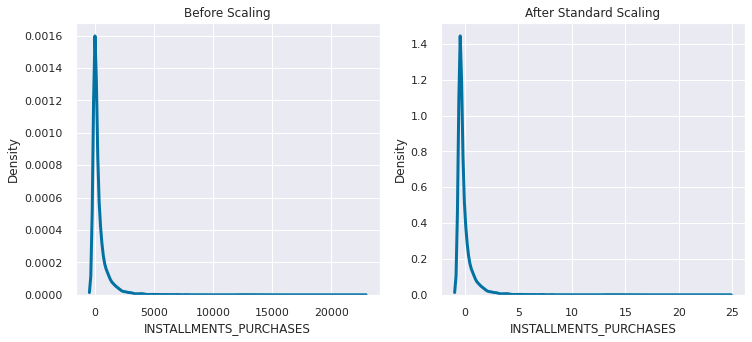

```
None
```

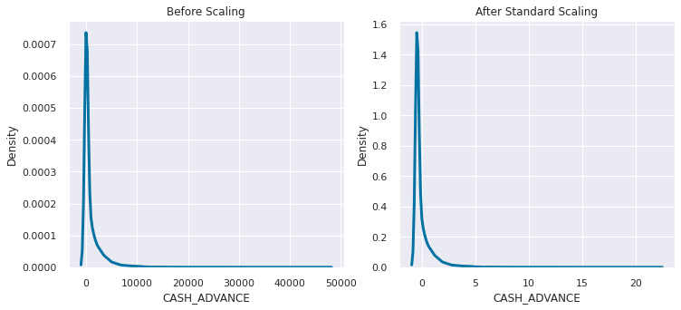

```
None
```

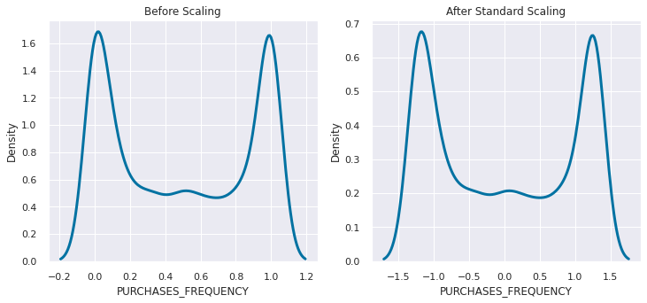

```
None
```

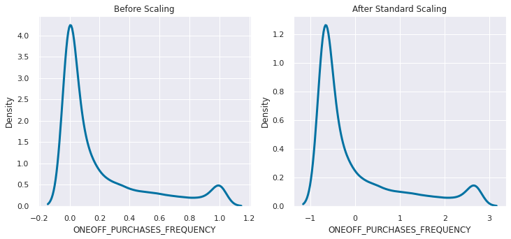

```
None
```

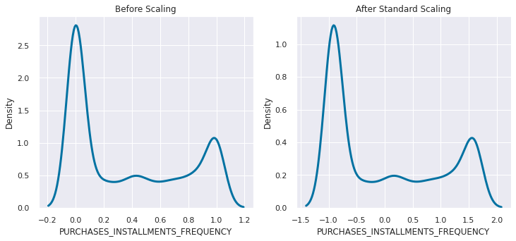

```
None
```

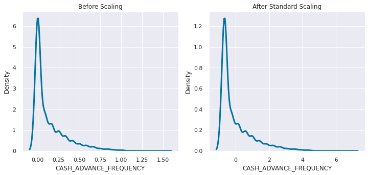

```
None
```

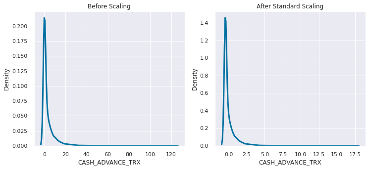

```
None
```

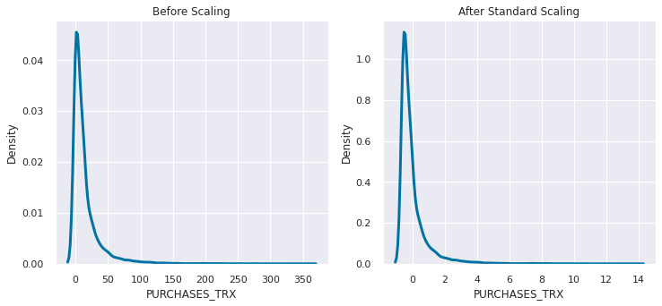

```
None
```

[5 more figures not shown]

```
None
```

```python
#a function to help check for differe in distribution between before scaling and after scaling the data
 def check_distribution(feature=str()):
  """
  Function to compare the distribution between scaled data and unscaled data
  """
 # let's compare the variable distributions before and after scaling

  fig, (ax1, ax2,) = plt.subplots(ncols=2, figsize=(12, 5))

# before scaling
  ax1.set_title('Before Scaling')
  sns.kdeplot(df[feature], linewidth=3, ax=ax1)

# # after scaling
  ax2.set_title('After Standard Scaling')
  sns.kdeplot(scaled_df[feature],linewidth=3, ax=ax2)
  plt.show()


for i in column_names:
  print(check_distribution(i))
```

Note from the above plots how standardisation centered all the distributions at zero, but it preserved their original distribution. The value range is not identical, but it looks more homogeneous across the variables.

So basically, the data is still the same only just transformed to enable compatibility with the models

# Principal Component Analysis

This is basically a statistical procedure to convert a set of observations of possibly correlated variables into a set of values of linearly uncorrelated variables. Each of the principal components is chosen in such a way so that it would describe most of them still available variance and all these principal components are orthogonal to each other. In all principal components first principal component has a maximum variance.

Uses of PCA:

- It is used to find inter-relation between variables in the data.
- It is used to interpret and visualize data.
- The number of variables is decreasing it makes further analysis simpler.
- It’s often used to visualize genetic distance and relatedness between populations

Objectives of PCA:

- It is basically a non-dependent procedure in which it reduces attribute space from a large number of variables to a smaller number of factors.
- PCA is basically a dimension reduction process but there is no guarantee that the dimension is interpretable.
- The main task in this PCA is to select a subset of variables from a larger set, based on which original variables have the highest correlation with the principal amount

In our case, the PCA will be used for feature reduction to enable us perform further analysis

```python
#dimension reduction
pca = PCA(n_components=2)
principal_components = pca.fit_transform(scaled_df)
pca_df = pd.DataFrame(data=principal_components ,columns=["PCA1","PCA2"])
pca_df.head(3)
```

|  | PCA1 | PCA2 |
| --- | --- | --- |
| 0 | -1.682221 | -1.076480 |
| 1 | -1.138295 | 2.506340 |
| 2 | 0.969681 | -0.383485 |

Above is our reduced data set, comprising of 2 components , PCA1 and PCA2.

Now that we are done with the preprocessing, it's good for us to take not of all the data sets created in all our previous codes. All data will be used during the model preparation.

The data available now are:

- df: The origin data, i.e the raw data, which as also been cleaned.
- scaled_df: The standardised scaled data
- pca_df: Principal component dataframe.

# USING KMEANS ALGORITHM

K Means Clustering is an unsupervised learning algorithm that will attempt to group similar clusters together in your data.

So what does a typical clustering problem look like?

In our case it's Cluster Customers based on Features.

The K Means Algorithm Process involves

- Choose a number of Clusters “K”
- Randomly assign each point to a cluster
- Until clusters stop changing, repeat the following:
  - For each cluster, compute the cluster centroid by taking the mean vector of points in the cluster
  - Assign each data point to the clusterfor which the centroid is the closest cluster

[figure not shown]